# Latent trait analysis

FOR EVERYTHING BELOW, I DROPPED OUT THE THREE “OTHER” RESPONSE OPTIONS FROM THE INCIDENCE MATRICES

A bunch of code is hiddend under the hood here to get this all set up….

```r
combos = data.table(melt(crossprod(Y)))[Var1!=Var2,]
combos = combos[as.numeric(combos$Var1) <= as.numeric(combos$Var2),]
combos$Var1 <- paste0(combos$Var1,' (',concept_types$Type[match(combos$Var1,concept_types$Vector)],')')
combos$Var2 <- paste0(combos$Var2,' (',concept_types$Type[match(combos$Var2,concept_types$Vector)],')')

htmlTable::htmlTable(combos[order(-value),][1:10,],caption ='top 10 combos')
```

| top 10 combos | top 10 combos Var1 | top 10 combos Var2 | top 10 combos value |
| --- | --- | --- | --- |
| 1 | Stormwater (Concern) | Transpo (Concern) | 251 |
| 2 | DACsC (Concern) | Transpo (Concern) | 188 |
| 3 | SLR Plan (Policy) | Transpo (Concern) | 184 |
| 4 | Overall Plan (Barrier) | Transpo (Concern) | 176 |
| 5 | Overall Plan (Barrier) | Stormwater (Concern) | 166 |
| 6 | SLR Plan (Policy) | Stormwater (Concern) | 162 |
| 7 | DACsC (Concern) | Stormwater (Concern) | 146 |
| 8 | Collab (Policy) | Transpo (Concern) | 144 |
| 9 | Collab (Policy) | Stormwater (Concern) | 138 |
| 10 | Overall Plan (Barrier) | SLR Plan (Policy) | 129 |

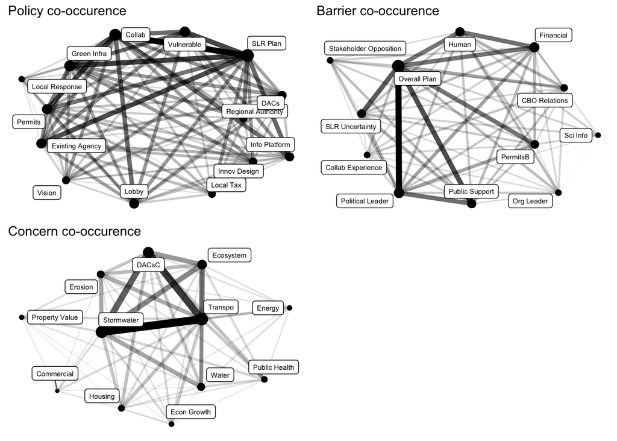

```r
require(htmlTable)
concept_unipartite = (crossprod(Y))

uni_net = as.network(concept_unipartite,matrix.type = 'adjacency',directed = F,ignore.eval = F,names.eval = 'cooccurence')

uni_net %v% 'Frequency' <- diag(concept_unipartite)

uni_net %v% 'Type' <- concept_types$Type[match(network.vertex.names(uni_net),concept_types$Vector)]
glist = lapply(c('Policy','Barrier','Concern'),function(x) get.inducedSubgraph(uni_net,v = which(uni_net %v% 'Type' == x)) %>% ggnetwork() %>%
         ggplot(.,aes(x = x,xend = xend,y = y,yend = yend,label = vertex.names))+
  geom_edges(aes(size = cooccurence/nrow(Y),alpha = cooccurence)) +
  geom_point(aes(size = Frequency/nrow(Y))) +
    ggtitle(paste(x,'co-occurence')) +
  geom_nodelabel_repel(size = 2) + theme_map() + guides(alpha = F,size = F) +
  scale_size_continuous(range = c(0.1,4))+
  theme(legend.position = c(0.8,0.2))
         )

grid.arrange(glist[[1]],glist[[2]],glist[[3]],ncol = 2)
```

```r
soc = as.sociomatrix(uni_net,attrname = 'cooccurence')
gov_types = c('Regional Authority','Existing Agency','Collab')
htmlTable(do.call(cbind,lapply(gov_types,function(x)
as.data.table(soc[x,],keep.rownames = T)[order(-V2),][1:10,][,V2:=paste0(V1,' (',round(V2/sum(Y[,x]),2),')')][,'V2'])),
header = gov_types,caption  = 'Top 10 choices by respondents who choose each governance preference',
tfoot = '# = proportion of respondents by governance strategy who also choose item')
```

| Top 10 choices by respondents who choose each governance preference | Top 10 choices by respondents who choose each governance preference Regional Authority | Top 10 choices by respondents who choose each governance preference Existing Agency | Top 10 choices by respondents who choose each governance preference Collab |
| --- | --- | --- | --- |
| 1 | Transpo (0.62) | Transpo (0.69) | Transpo (0.59) |
| 2 | DACsC (0.54) | Stormwater (0.56) | Stormwater (0.57) |
| 3 | Stormwater (0.49) | DACsC (0.51) | Overall Plan (0.45) |
| 4 | Overall Plan (0.43) | Overall Plan (0.47) | DACsC (0.42) |
| 5 | SLR Plan (0.4) | SLR Plan (0.36) | Ecosystem (0.35) |
| 6 | Ecosystem (0.33) | Political Leader (0.29) | SLR Plan (0.33) |
| 7 | Green Infra (0.29) | Ecosystem (0.27) | Financial (0.27) |
| 8 | Political Leader (0.26) | Collab (0.21) | Political Leader (0.27) |
| 9 | Financial (0.22) | Permits (0.21) | Human (0.22) |
| 10 | Human (0.22) | Vulnerable (0.21) | Permits (0.22) |

# = proportion of respondents by governance strategy who also choose item

```r
htmlTable(cbind(as.data.table(soc['Regional Authority',],keep.rownames = T)[order(-V2),][1:10,1],
as.data.table(soc['Existing Agency',],keep.rownames = T)[order(-V2),][1:10,1],
as.data.table(soc['Collab',],keep.rownames = T)[order(-V2),][1:10,1]))
```

|  | V1 | V1 | V1 |
| --- | --- | --- | --- |
| 1 | Transpo | Transpo | Transpo |
| 2 | DACsC | Stormwater | Stormwater |
| 3 | Stormwater | DACsC | Overall Plan |
| 4 | Overall Plan | Overall Plan | DACsC |
| 5 | SLR Plan | SLR Plan | Ecosystem |
| 6 | Ecosystem | Political Leader | SLR Plan |
| 7 | Green Infra | Ecosystem | Financial |
| 8 | Political Leader | Collab | Political Leader |
| 9 | Financial | Permits | Human |
| 10 | Human | Vulnerable | Permits |

Latent class analysis (LCA) and latent trait analysis (LTA) are similar in principle. Both can be fit to binary incidence matrices X_nm where N = # of respondents and M = # of response items. A given X_nm value is respondent n’s 0 or 1 choice for item m. The difference between LCA and LTA is that LCA assumes that there is a latent categorical variable representing groups of N’s (respondents), and response items are independent conditional on group membership. In other words, the estimated probability of choosing a given response item is conditional on group membership. LTA essentially works in reverse – this model assumes that response variables (e.g., policy concepts in our case) are represented by a D-dimensional continuous latent variable (with D specified prior to fitting). In other words, whereas LCA groups respondents, LTA groups responses. There’s a lot of fancy approximation math under the hood that is beyond the scope here.

```r
#### note -- mlta takes vectors instead of single D and G values -- but pblapply is used to parallelize #####
max_dims = 2
max_groups = 3
opts = data.table(expand.grid(D = 0:max_dims,G = 1:max_groups,fix = c(F,T)))
opts = opts[D>0|!fix,]
### this part takes a while, so I commented out and upload an RDS at the end ###
require(doParallel)
cluster = makeCluster(4)
registerDoParallel(cluster)
clusterExport(cl = cluster,varlist = list('opts','Y'))
clusterEvalQ(cl = cluster,require(lvm4net))
```

```
## [[1]]
## [1] TRUE
##
## [[2]]
## [1] TRUE
##
## [[3]]
## [1] TRUE
##
## [[4]]
## [1] TRUE
```

```r
mlta_tests = foreach(i = 1:nrow(opts)) %dopar% {mlta(X = Y, D = opts$D[i], G = opts$G[i],wfix = opts$fix[i],nstarts = 5,maxiter = 1e3)}

saveRDS(mlta_tests,'scratch/mlta_results.rds')

mlta_tests = readRDS('scratch/mlta_results.rds')
mlta_results = data.table(opts,BIC = sapply(mlta_tests,function(x) x$BIC))
mlta_results$G_fix = paste0('G = ',mlta_results$G,' (fixed slope = ',mlta_results$fix,')')
mlta_results$BIC <- round(mlta_results$BIC)
mlta_cast = dcast(mlta_results[order(BIC)],G_fix ~ D,value.var = 'BIC')

htmlTable(mlta_cast[,-1],caption = 'BIC scores by MLTA specification',rnames = mlta_cast$G_fix,header = paste0('D = ',0:max_dims),
          tfoot = '*fixed slope refers to whether slope is constant across all groups are group-specific')
```

| BIC scores by MLTA specification | BIC scores by MLTA specification D = 0 | BIC scores by MLTA specification D = 1 | BIC scores by MLTA specification D = 2 |
| --- | --- | --- | --- |
| G = 1 (fixed slope = FALSE) | 23729 | 23776 | 23883 |
| G = 1 (fixed slope = TRUE) |  | 23776 | 23883 |
| G = 2 (fixed slope = FALSE) | 23745 | 23966 | 24272 |
| G = 2 (fixed slope = TRUE) |  | 23847 | 23979 |
| G = 3 (fixed slope = FALSE) | 23837 | 24258 | 24773 |
| G = 3 (fixed slope = TRUE) |  | 23939 | 24086 |

*fixed slope refers to whether slope is constant across all groups are group-specific

So, the lamest thing here is that apparently the model with 1 group and 0 latent dimensions is the best…. i.e., a LCA model with no subgroups. SAD! The fact that G = 1, D = 0 is the best fitting model doesn’t mean there are no distinctions, is just means they aren’t super strong.

That said, the 2-group, 1 dimensional model with fixed slopes (i.e., a single item-specific slope parameter across all groups) is pretty close though in terms of BIC, so we can play with that a bit and see what distinctions arise. To briefly elaborate on what the intercepts and slopes mean – each response item is a logistic function. That function then varies by group. Intercepts reflect the basic propensity for group members to choose an item, in addictive log odds. A higher intercept means group members are more likely to choose an item, and vice versa. Slopes represent heterogeneity amongst actors who choose a given concept. Heterogeneity is measured in terms of the latent trait variable. In other words, heterogeneity refers to the dependenence structure amongst items chosen by members of a given group. That said, we are going to ignore the slopes for now.

The first thing we can look at is the posterior probability of respondents falling into each of the two groups (latent classes)

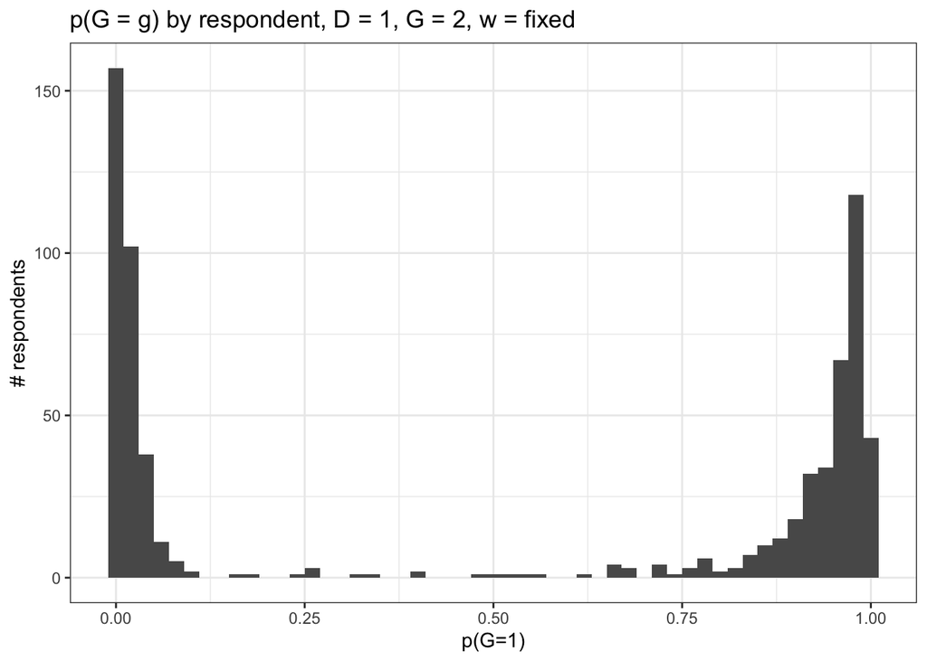

```r
index = which(opts$D==1&opts$G==2&opts$fix==T)
betas = mlta_tests[[index]]$b
wus = mlta_tests[[index]]$w
group_probs = mlta_tests[[index]]$z
colnames(betas) <- colnames(wus) <- colnames(Y)

ggplot() + geom_histogram(aes(x =group_probs[,1]),binwidth = 0.02) + theme_bw() + ggtitle('p(G = g) by respondent, D = 1, G = 2, w = fixed') +
  ylab('# respondents') + xlab('p(G=1)')
```

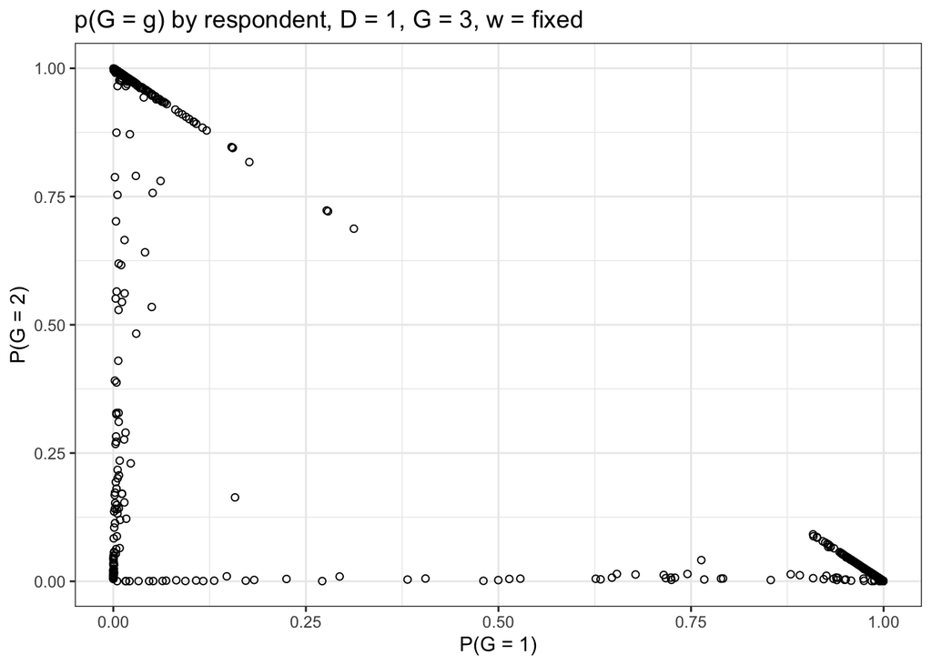

```r
index2 = which(opts$D==1&opts$G==3&opts$fix==T)
group_probs = mlta_tests[[index2]]$z

ggplot() + geom_point(aes(x = group_probs[,1],y = group_probs[,2]),pch = 21) + theme_bw() + xlab('P(G = 1)') + ylab('P(G = 2)') +
  ggtitle('p(G = g) by respondent, D = 1, G = 3, w = fixed')
```

Anyways, we can then evaluate the intercept terms in each logistic response function to identify which items load heavily by group. Ignoring the model slope parameters. Here, it’s clear that some items are identified by both groups (e.g., stormwater, transportation) while others are more excluvisely related to one and not the other (e.g., concern about DACs). Some are rare in both, like “commercial” and “property value”. This also begins to reveal why increased dimensionality doens’t seem to help model fit very much, many items are about as likely to be selected by one group as the other. Heuristically, items below the dashed line are more strongly associated with Group 1, and above are more strongly associated with Group 2.

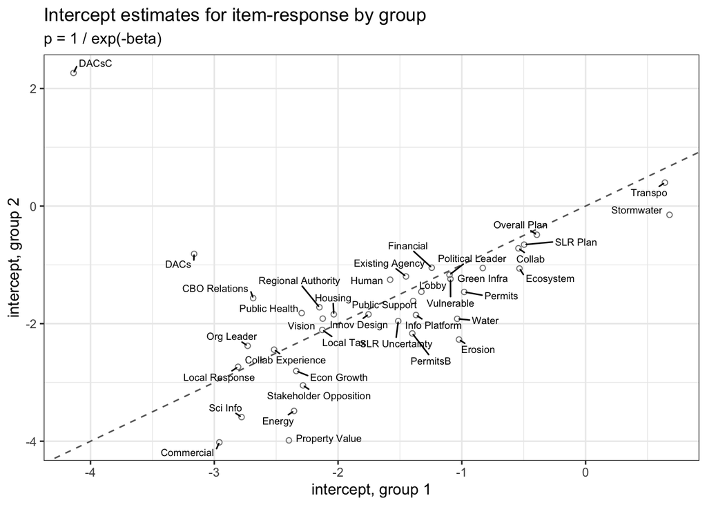

```r
beta_dt = data.table(t(betas),keep.rownames = T)
ggplot(beta_dt,aes(x = `Group 1`,y = `Group 2`,label = rn)) + geom_abline(lty = 2,col = 'grey40') +
  geom_point(pch = 21,col = 'grey50') + geom_text_repel(size = 2.5,max.overlaps = 100,min.segment.length = 0.2) +
  xlab('intercept, group 1') + ylab('intercept, group 2') + theme_bw() + ggtitle('Intercept estimates for item-response by group','p = 1 / exp(-beta)')
```

There are all sorts of (or at least a few) other things we could do with the intercepts and slopes, and evaluate the same measures fit to other combinations of G (group) and D (latent trait) values. But for now, let’s check out the correspondence between particular items within groups. This can be measured using “lift”. Lift refers to the dependence between ties, in this case measured by group. So, focusing first on group 1, we can compute and plot the lift between each pair of response items. Independent positive responses have a lift value of 1. Values greater than 1 imply positive dependence, and < 1 negative dependence. In other words, this is similar to fitting matching terms in an ERGM –> “how does a tie to one particular concept affect the probability of a tie to another concept?”. Lift values are then logged so that log-lift values < 0 imply a negative association and > 0 a positive association.

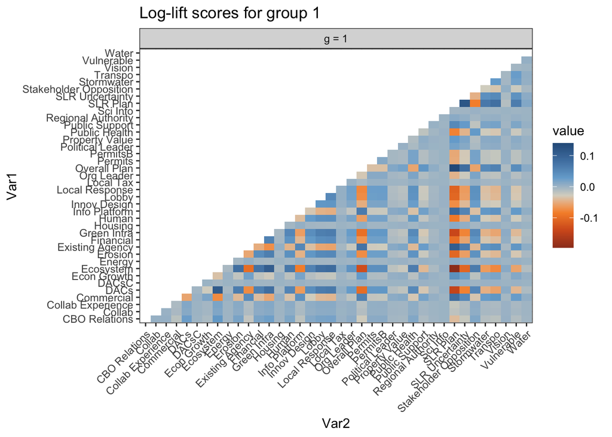

```r
loglift <- log(lift(mlta_tests[[index]], pdGH = 21))
colnames(loglift) <- colnames(Y)[as.numeric(colnames(loglift))]
rownames(loglift) <- colnames(Y)[as.numeric(rownames(loglift))]

lift_dt = data.table(melt(loglift))
ggplot(data = lift_dt[Var3=='g = 1',],aes(x = Var2,y = Var1,fill = value,group = Var3)) + facet_wrap(~Var3) + geom_tile() + theme_bw() +
    ggtitle('Log-lift scores for group 1')+
  scale_fill_gradient2_tableau(palette = 'Orange-Blue Diverging',na.value = 'white') + theme(axis.text.x = element_text(angle = 45,hjust = 1))
```

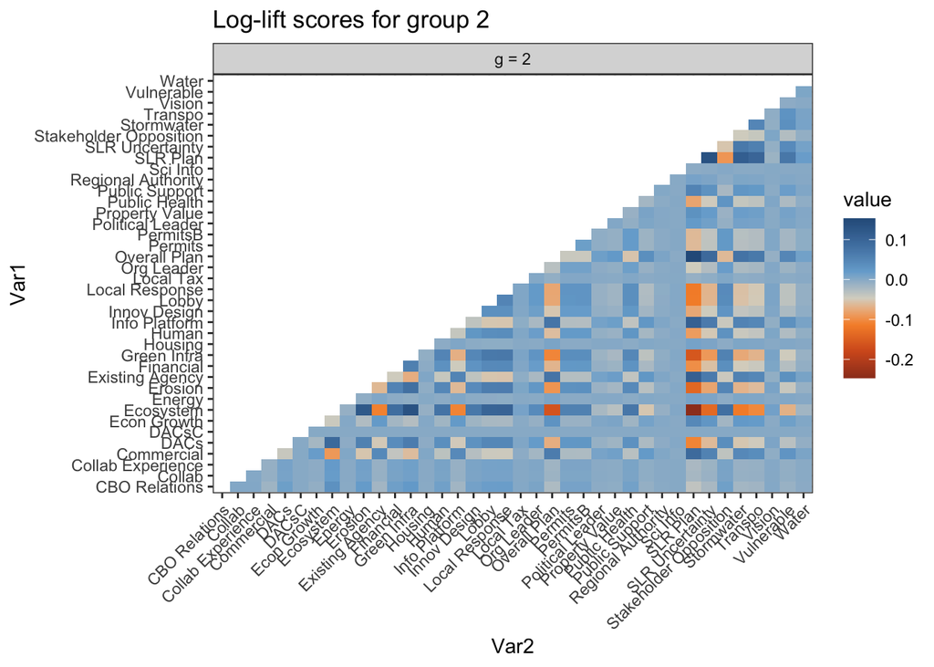

```r
ggplot(data = lift_dt[Var3=='g = 2',],aes(x = Var2,y = Var1,fill = value,group = Var3)) + facet_wrap(~Var3) + geom_tile() + theme_bw() +
  ggtitle('Log-lift scores for group 2')+
  scale_fill_gradient2_tableau(palette = 'Orange-Blue Diverging',na.value = 'white') + theme(axis.text.x = element_text(angle = 45,hjust = 1))
```

Group 2 looks relatively similar.